# GC_Content

Friday 5th November 2021

In response to some reviewer comment, let’s look at GC content of the genes involved. At this moment in time I do not have the non-canon list finalised so will only go so far as to do some data manipulation and look at the canon genes.

```r
gc <- read.table("input/GC/gc_Content.tsv", header = T, sep = "\t")
head(gc)
```

|  | Gene | AlnLength | Amel | Aflo | Bimp | Bter | Ccal | Dnov | Emex | Hlab | Lalb | Mqua | Mrot |
| --- | --- | --- | --- | --- | --- | --- | --- | --- | --- | --- | --- | --- | --- |
| 1 | 5-HT1 | 1152 | 55.47 | 55.73 | 53.91 | 52.43 | 52.69 | 55.47 | 56.34 | 54.95 | 57.38 | 54.25 | 54.25 |
| 2 | 5-ht7 | 666 | 48.65 | 50.15 | 51.95 | 47.15 | 56.61 | 51.65 | 54.65 | 52.40 | 55.41 | 51.95 | 50.30 |
| 3 | A4 | 510 | 37.45 | 36.86 | 41.76 | 41.57 | 48.82 | 47.65 | 41.76 | 46.08 | 49.61 | 45.88 | 44.12 |
| 4 | Acph-1 | 1185 | 40.59 | 40.42 | 39.75 | 40.00 | 43.38 | 43.12 | 38.73 | 39.41 | 43.80 | 41.27 | 40.84 |
| 5 | ACSF2 | 888 | 47.75 | 47.64 | 46.17 | 45.16 | 50.00 | 55.74 | 50.45 | 51.58 | 57.21 | 44.03 | 51.91 |
| 6 | Adar | 1671 | 40.16 | 40.10 | 41.53 | 41.41 | 49.43 | 49.97 | 42.43 | 46.02 | 52.54 | 43.33 | 45.48 |

Add a all species average column

```r
gc <- gc[!duplicated(gc),]
rownames(gc) <- gc$Gene
gc$Gene <- NULL
head(gc)
```

|  | AlnLength | Amel | Aflo | Bimp | Bter | Ccal | Dnov | Emex | Hlab | Lalb | Mqua | Mrot |
| --- | --- | --- | --- | --- | --- | --- | --- | --- | --- | --- | --- | --- |
| 5-HT1 | 1152 | 55.47 | 55.73 | 53.91 | 52.43 | 52.69 | 55.47 | 56.34 | 54.95 | 57.38 | 54.25 | 54.25 |
| 5-ht7 | 666 | 48.65 | 50.15 | 51.95 | 47.15 | 56.61 | 51.65 | 54.65 | 52.40 | 55.41 | 51.95 | 50.30 |
| A4 | 510 | 37.45 | 36.86 | 41.76 | 41.57 | 48.82 | 47.65 | 41.76 | 46.08 | 49.61 | 45.88 | 44.12 |
| Acph-1 | 1185 | 40.59 | 40.42 | 39.75 | 40.00 | 43.38 | 43.12 | 38.73 | 39.41 | 43.80 | 41.27 | 40.84 |
| ACSF2 | 888 | 47.75 | 47.64 | 46.17 | 45.16 | 50.00 | 55.74 | 50.45 | 51.58 | 57.21 | 44.03 | 51.91 |
| Adar | 1671 | 40.16 | 40.10 | 41.53 | 41.41 | 49.43 | 49.97 | 42.43 | 46.02 | 52.54 | 43.33 | 45.48 |

```r
gc$GeneAverage <- rowMeans(gc[, c(2:12)])
head(gc)
```

|  | AlnLength | Amel | Aflo | Bimp | Bter | Ccal | Dnov | Emex | Hlab | Lalb | Mqua | Mrot | GeneAverage |
| --- | --- | --- | --- | --- | --- | --- | --- | --- | --- | --- | --- | --- | --- |
| 5-HT1 | 1152 | 55.47 | 55.73 | 53.91 | 52.43 | 52.69 | 55.47 | 56.34 | 54.95 | 57.38 | 54.25 | 54.25 | 54.80636 |
| 5-ht7 | 666 | 48.65 | 50.15 | 51.95 | 47.15 | 56.61 | 51.65 | 54.65 | 52.40 | 55.41 | 51.95 | 50.30 | 51.89727 |
| A4 | 510 | 37.45 | 36.86 | 41.76 | 41.57 | 48.82 | 47.65 | 41.76 | 46.08 | 49.61 | 45.88 | 44.12 | 43.77818 |
| Acph-1 | 1185 | 40.59 | 40.42 | 39.75 | 40.00 | 43.38 | 43.12 | 38.73 | 39.41 | 43.80 | 41.27 | 40.84 | 41.02818 |
| ACSF2 | 888 | 47.75 | 47.64 | 46.17 | 45.16 | 50.00 | 55.74 | 50.45 | 51.58 | 57.21 | 44.03 | 51.91 | 49.78545 |
| Adar | 1671 | 40.16 | 40.10 | 41.53 | 41.41 | 49.43 | 49.97 | 42.43 | 46.02 | 52.54 | 43.33 | 45.48 | 44.76364 |

Add the runs with averages of the branches included

```r
gc$Solitary <- rowMeans(gc[, c("Dnov", "Hlab", "Mrot")])
gc$SocialCorb <- rowMeans(gc[, c("Bter", "Bimp", "Emex", "Mqua")])
gc$Social <- rowMeans(gc[, c("Bter", "Bimp", "Ccal", "Emex", "Mqua", "Lalb")])
gc$AdvancedEusocial <- rowMeans(gc[, c("Amel", "Aflo", "Mqua")])
gc$Apis <- rowMeans(gc[, c("Amel", "Aflo")])

head(gc)
```

|  | AlnLength | Amel | Aflo | Bimp | Bter | Ccal | Dnov | Emex | Hlab | Lalb | Mqua | Mrot | GeneAverage | Solitary | SocialCorb | Social | AdvancedEusocial | Apis |
| --- | --- | --- | --- | --- | --- | --- | --- | --- | --- | --- | --- | --- | --- | --- | --- | --- | --- | --- |
| 5-HT1 | 1152 | 55.47 | 55.73 | 53.91 | 52.43 | 52.69 | 55.47 | 56.34 | 54.95 | 57.38 | 54.25 | 54.25 | 54.80636 | 54.89000 | 54.2325 | 54.50000 | 55.15000 | 55.600 |
| 5-ht7 | 666 | 48.65 | 50.15 | 51.95 | 47.15 | 56.61 | 51.65 | 54.65 | 52.40 | 55.41 | 51.95 | 50.30 | 51.89727 | 51.45000 | 51.4250 | 52.95333 | 50.25000 | 49.400 |
| A4 | 510 | 37.45 | 36.86 | 41.76 | 41.57 | 48.82 | 47.65 | 41.76 | 46.08 | 49.61 | 45.88 | 44.12 | 43.77818 | 45.95000 | 42.7425 | 44.90000 | 40.06333 | 37.155 |
| Acph-1 | 1185 | 40.59 | 40.42 | 39.75 | 40.00 | 43.38 | 43.12 | 38.73 | 39.41 | 43.80 | 41.27 | 40.84 | 41.02818 | 41.12333 | 39.9375 | 41.15500 | 40.76000 | 40.505 |
| ACSF2 | 888 | 47.75 | 47.64 | 46.17 | 45.16 | 50.00 | 55.74 | 50.45 | 51.58 | 57.21 | 44.03 | 51.91 | 49.78545 | 53.07667 | 46.4525 | 48.83667 | 46.47333 | 47.695 |
| Adar | 1671 | 40.16 | 40.10 | 41.53 | 41.41 | 49.43 | 49.97 | 42.43 | 46.02 | 52.54 | 43.33 | 45.48 | 44.76364 | 47.15667 | 42.1750 | 45.11167 | 41.19667 | 40.130 |

```r
head(omega)
```

|  | Gene | dN.dS | Class |
| --- | --- | --- | --- |
| 1 | 5-HT1 | 0.08365 | Random |
| 2 | 5-ht7 | 0.12095 | Random |
| 3 | A4 | 0.19851 | Random |
| 4 | Acph-1 | 0.20930 | Random |
| 5 | ACSF2 | 0.15856 | Random |
| 6 | Adar | 0.03833 | Random |

Just looking at dNdS and GC ….

```r
dNdS <- omega[,c(1:2)]
head(dNdS)
```

|  | Gene | dN.dS |
| --- | --- | --- |
| 1 | 5-HT1 | 0.08365 |
| 2 | 5-ht7 | 0.12095 |
| 3 | A4 | 0.19851 |
| 4 | Acph-1 | 0.20930 |
| 5 | ACSF2 | 0.15856 |
| 6 | Adar | 0.03833 |

```r
gc$Gene <- rownames(gc)
gc.avg <- gc[, c("Gene", "AlnLength", "GeneAverage")]
rownames(gc.avg) <- NULL
head(gc.avg)
```

|  | Gene | AlnLength | GeneAverage |
| --- | --- | --- | --- |
| 1 | 5-HT1 | 1152 | 54.80636 |
| 2 | 5-ht7 | 666 | 51.89727 |
| 3 | A4 | 510 | 43.77818 |
| 4 | Acph-1 | 1185 | 41.02818 |
| 5 | ACSF2 | 888 | 49.78545 |
| 6 | Adar | 1671 | 44.76364 |

```r
dvg <- merge(dNdS, gc.avg, by = "Gene", all.x = T)
```

Lost some genes here but it’ll only be the ones that failed to work in codeml

```r
head(dvg)
```

|  | Gene | dN.dS | AlnLength | GeneAverage |
| --- | --- | --- | --- | --- |
| 1 | 5-HT1 | 0.08365 | 1152 | 54.80636 |
| 2 | 5-ht7 | 0.12095 | 666 | 51.89727 |
| 3 | A4 | 0.19851 | 510 | 43.77818 |
| 4 | Acph-1 | 0.20930 | 1185 | 41.02818 |
| 5 | ACSF2 | 0.15856 | 888 | 49.78545 |
| 6 | Adar | 0.03833 | 1671 | 44.76364 |

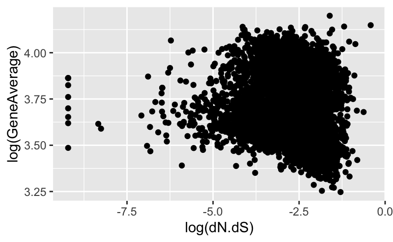

```r
library(ggplot2)

ggplot(dvg, aes(x = log(dN.dS), y = log(GeneAverage))) +
  geom_point()
```

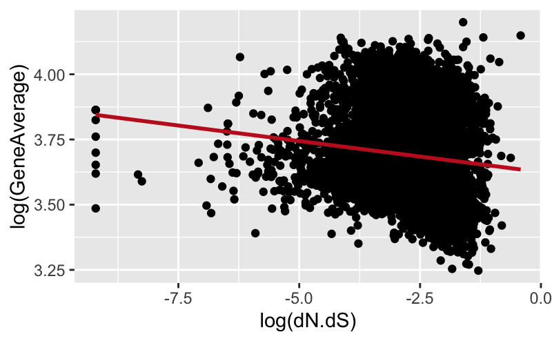

```r
p <- ggplot(dvg, aes(x = log(dN.dS), y = log(GeneAverage))) +
  geom_point(colour = "black") +
  stat_smooth(method = "lm",
        col = "#C42126",
        se = FALSE,
        size = 1)

p
```

If anything, higher evolutionary rate is associated with lower GC content …